# Biostat M280 Homework 4

Due Mar 16 @ 11:59PM

Landi Luo (UID: 305027205)

3/9/2018

```r
if (!require("pacman"))
  install.packages("pacman", repos = "http://cran.us.r-project.org/")
p_load("sparklyr", "dplyr", "ggplot2", "ggmap", "maps", "mapdata", "knitr",
       "ggrepel", "RColorBrewer", "lubridate", "readr")
```

Our Apache Yarn cluster hosts the [flights](http://stat-computing.org/dataexpo/2009/the-data.html) data representing 123 million flights over 22 years. Read the [lecture notes](http://hua-zhou.github.io/teaching/biostatm280-2018winter/slides/12-sparklyr/sparklyr-flights.html) on how to access the Yarn cluster. Connect to the database using `sparklyr` and answer following questions. You can base your answers on a specific year or the whole data set.

```r
# connect to spark
Sys.setenv(SPARK_HOME="/usr/lib/spark")
config <- spark_config()
sc <- spark_connect(master = "local", config = config)
sc
```

*Create dplyr reference to the Spark DataFrame.*

```r
flights_tbl <- tbl(sc, 'flights')
airlines_tbl <- tbl(sc, 'airlines')
airports_tbl <- tbl(sc, 'airports')

flights_tbl
```

```
## # Source:   table<flights> [?? x 29]
## # Database: spark_connection
##     year month dayofmonth dayofweek deptime crsdeptime arrtime crsarrtime
##    <int> <int>      <int>     <int>   <int>      <int>   <int>      <int>
##  1    NA    NA         NA        NA      NA         NA      NA         NA
##  2  1987    10         14         3     741        730     912        849
##  3  1987    10         15         4     729        730     903        849
##  4  1987    10         17         6     741        730     918        849
##  5  1987    10         18         7     729        730     847        849
##  6  1987    10         19         1     749        730     922        849
##  7  1987    10         21         3     728        730     848        849
##  8  1987    10         22         4     728        730     852        849
##  9  1987    10         23         5     731        730     902        849
## 10  1987    10         24         6     744        730     908        849
## # ... with more rows, and 21 more variables: uniquecarrier <chr>,
## #   flightnum <int>, tailnum <chr>, actualelapsedtime <int>,
## #   crselapsedtime <int>, airtime <chr>, arrdelay <int>, depdelay <int>,
## #   origin <chr>, dest <chr>, distance <int>, taxiin <chr>, taxiout <chr>,
## #   cancelled <int>, cancellationcode <chr>, diverted <int>,
## #   carrierdelay <chr>, weatherdelay <chr>, nasdelay <chr>,
## #   securitydelay <chr>, lateaircraftdelay <chr>
```

```r
airlines_tbl
```

```
## # Source:   table<airlines> [?? x 2]
## # Database: spark_connection
##    code  description
##    <chr> <chr>
##  1 Code  Description
##  2 02Q   Titan Airways
##  3 04Q   Tradewind Aviation
##  4 05Q   Comlux Aviation, AG
##  5 06Q   Master Top Linhas Aereas Ltd.
##  6 07Q   Flair Airlines Ltd.
##  7 09Q   Swift Air, LLC d/b/a Eastern Air Lines d/b/a Eastern
##  8 0BQ   DCA
##  9 0CQ   ACM AIR CHARTER GmbH
## 10 0FQ   Maine Aviation Aircraft Charter, LLC
## # ... with more rows
```

```r
airports_tbl
```

```
## # Source:   table<airports> [?? x 12]
## # Database: spark_connection
##    id    name  city  country faa   icao  lat   lon   alt   tz_offset dst
##    <chr> <chr> <chr> <chr>   <chr> <chr> <chr> <chr> <chr> <chr>     <chr>
##  1 1     Goro… Goro… Papua … GKA   AYGA  -6.0… 145.… 5282  10        U
##  2 2     Mada… Mada… Papua … MAG   AYMD  -5.2… 145.… 20    10        U
##  3 3     Moun… Moun… Papua … HGU   AYMH  -5.8… 144.… 5388  10        U
##  4 4     Nadz… Nadz… Papua … LAE   AYNZ  -6.5… 146.… 239   10        U
##  5 5     Port… Port… Papua … POM   AYPY  -9.4… 147.… 146   10        U
##  6 6     Wewa… Wewak Papua … WWK   AYWK  -3.5… 143.… 19    10        U
##  7 7     Nars… Nars… Greenl… UAK   BGBW  61.1… -45.… 112   -3        E
##  8 8     Godt… Godt… Greenl… GOH   BGGH  64.1… -51.… 283   -3        E
##  9 9     Kang… Sond… Greenl… SFJ   BGSF  67.0… -50.… 165   -3        E
## 10 10    Thul… Thule Greenl… THU   BGTL  76.5… -68.… 251   -4        E
## # ... with more rows, and 1 more variable: tz_name <chr>
```

1. Map the top 10 busiest airports. Size of dots should reflect the number of flights through that destination.  
   Hint: You may find this tutorial on [Making Maps in R](http://eriqande.github.io/rep-res-web/lectures/making-maps-with-R.html) helpful.  
   *I mapped the top 10 busiest airports from the year 2002 by counting the total flights that took-off and landed from each airport. The busiest airport was Chicago O’Hare International Airport (ORD), which had 654,782 total flights.*

[figure not shown]

   ```r
   # subset flights from 2002
   flights_yr <- flights_tbl %>%
     filter(year == 2002)

   flights_orig <- flights_yr %>%
     # remove first row
     filter(origin != "Origin") %>%
     select(year, "airport" = origin)
   flights_dest <- flights_yr %>%
     filter(dest != "Dest") %>%
     select(year, "airport" = dest)
   combine_orig <- flights_orig %>%
     group_by(airport) %>%
     summarise(n = n()) %>%
     collect()
   combine_dest <- flights_dest %>%
     group_by(airport) %>%
     summarise(n = n()) %>%
     collect()
   combined <- bind_rows(combine_orig, combine_dest) %>%
     group_by(airport) %>%
     summarise(`Total Flights` = sum(n)) %>%
     arrange(desc(`Total Flights`)) %>%
     head(10)

   # create vector with top 10 airport names
   target <- combined$airport

   airports2 <- airports_tbl %>%
     select(faa, lat, lon, name) %>%
     filter(faa %in% target) %>%
     collect()
   q1 <- left_join(combined, airports2, by = c("airport" = "faa"))
   # write_csv(q1, "finalq1.csv")

   ## generate map ##

   # convert lat and lon to numeric
   q1$lat <- as.numeric(q1$lat)
   q1$lon <- as.numeric(q1$lon)

   map <- get_googlemap(location = 'united states', zoom = 4)
   top_airports <- ggmap(map) +
     geom_point(aes(x = lon, y = lat, size = `Total Flights`),
                data = q1, alpha = .5) +
     labs(x = "Longitude", y = "Latitude",
          title = "Top 10 Busiest Airports in 2002") +
     geom_label_repel(data = q1, label = q1$airport, size = 2)
   top_airports
   ```

   ```r
   kable(combined, col.names = c("Airport", "Total Flights"), align = "l")
   ```

   | Airport | Total Flights |
   | --- | --- |
   | ORD | 654782 |
   | DFW | 562709 |
   | ATL | 463826 |
   | LAX | 364835 |
   | PHX | 347880 |
   | MSP | 283074 |
   | DTW | 281357 |
   | STL | 265157 |
   | LAS | 261191 |
   | DEN | 240662 |

2. Map the top 10 busiest direct routes. Size of lines should reflect the number of flights through that route.  
   *I mapped the top 10 busiest direct routes for the year 2002. The busiest direct route was from LAX to LAS, with a total of 12,733 flights from 2002.*

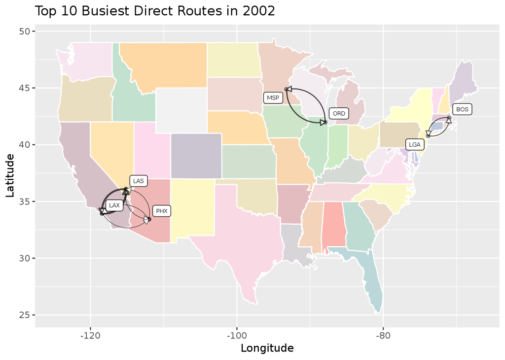

   ```r
   # get top 10 busiest routes
   routes <- flights_yr %>%
     filter(origin != "Origin") %>%
     select(year, origin, dest) %>%
     group_by(origin, dest) %>%
     summarise(n = n()) %>%
     collect() %>%
     arrange(desc(n)) %>%
     head(10) %>%
     ungroup()

   # get latitude and longitude for origin and dest
   orig_vector <- routes$origin
   airports_orig <- airports_tbl %>%
     select(faa, lat, lon, name) %>%
     filter(faa %in% orig_vector) %>%
     collect()
   location_orig <- left_join(routes, airports_orig,
                              by = c("origin" = "faa")) %>%
     select(n, origin, lat_orig = lat, lon_orig = lon)

   dest_vector <- routes$dest
   airports_dest <- airports_tbl %>%
     select(faa, lat, lon, name) %>%
     filter(faa %in% dest_vector) %>%
     collect()
   location_dest <- left_join(routes, airports_dest,
                              by = c("dest" = "faa")) %>%
     select(dest, lat_dest = lat, lon_dest = lon)

   # combine into one dataframe
   q2 <- bind_cols(location_orig, location_dest)
   # write_rds(q2, "q2.rds")
   # q2 <- read_rds("q2.rds")

   ## generate map ##

   q2 <- q2 %>%
     mutate(scale = (n / max(n)) ^ 10)

   q2$lat_orig <- as.numeric(q2$lat_orig)
   q2$lon_orig <- as.numeric(q2$lon_orig)
   q2$lat_dest <- as.numeric(q2$lat_dest)
   q2$lon_dest <- as.numeric(q2$lon_dest)

   usa <- map_data("usa")
   state <- map_data("state")

   # customize region fill colors
   getPalette <- colorRampPalette(brewer.pal(9, "Pastel1"))

   # get map labels
   q2label <- q2 %>%
     select(origin, lat_orig, lon_orig) %>%
     distinct(origin, .keep_all = TRUE)

   top_routes <- ggplot(data = state) +
     geom_polygon(aes(x = long, y = lat, fill = region, group = group),
                  color = "white") +
                 coord_fixed(1.3) + guides(fill = FALSE) +
     geom_point(data = q2, aes(x = lon_orig, y = lat_orig), alpha = 0.2 ) +
     geom_point(data = q2, aes(x = lon_dest, y = lat_dest), alpha = 0.2) +
     geom_curve(data = q2, aes(x = lon_orig, y = lat_orig,
                               xend = lon_dest, yend = lat_dest),
                arrow = arrow(length = unit(0.2, "cm"), type = "closed"),
                alpha = 0.7, size = q2$scale) +
     geom_label_repel(aes(x = lon_orig, y = lat_orig), data = q2label,
                      label = q2label$origin, size = 2) +
     labs(x = "Longitude", y = "Latitude",
          title = "Top 10 Busiest Direct Routes in 2002") +
     scale_fill_manual(values = getPalette(49)) +
     coord_cartesian()
   top_routes
   ```

   ```r
   kable(routes, col.names = c("Origin", "Destination", "Number of Flights"),
         align = "l")
   ```

   | Origin | Destination | Number of Flights |
   | --- | --- | --- |
   | LAX | LAS | 12733 |
   | LAS | LAX | 12526 |
   | MSP | ORD | 12007 |
   | ORD | MSP | 11907 |
   | BOS | LGA | 11539 |
   | LGA | BOS | 11537 |
   | LAS | PHX | 11143 |
   | PHX | LAS | 11091 |
   | PHX | LAX | 11066 |
   | LAX | PHX | 11027 |

   ```r
   top_routes2 <- ggmap(map) +
     geom_point(data = q2, aes(x = lon_orig, y = lat_orig), alpha = 0.2 ) +
     geom_point(data = q2, aes(x = lon_dest, y = lat_dest), alpha = 0.2) +
     geom_curve(data = q2, aes(x = lon_orig, y = lat_orig,
                               xend = lon_dest, yend = lat_dest),
                arrow = arrow(length = unit(0.2, "cm"), type = "closed"),
                alpha = 0.7, size = q2$scale, color = "red") +
     labs(x = "Longitude", y = "Latitude",
          title = "Top 10 Busiest Direct Routes in 2002") +
     coord_cartesian()
   top_routes2
   ```

3. LAX:

   (a). Reproduce above plot. Visualize and explain some prominent features you observe. For example, what happened at points 1-5?  
   *I reproduced the plot of LAX air traffic from 1998 to 2008. The y-axis represents the number of flights in a day, and the x-axis represents the date. I zoomed in on points 1 - 5. A dramatic decrease in the number of flights to/from LAX is observed at point 1 (around the end of 2001). This may be explained by the September 11 attacks, as the decrease occurred right after that time period. The September 11 attacks significantly affected the number of flights, as the flights per day from LAX dropped from around 1400 to a low of around 800 flights towards the end of 2001. The number of flights also decreased drastically at points 2 and 3. The number of flights on Point 2 (November 25, 2004) was also significantly lower than the days around it (see zoomed-in plot). November 25, 2004 was Thanksgiving Day, which explains why the number of flights that day was significantly lower, as people usually fly before or after holidays but not on the holiday itself. The dramatic decrease in the number of flights on Point 3 (July 4, 2004) can also be explained by this reason, as it was Independence Day. There is also a drop in flights around point 4 (end of 2007/beginning of 2008). This may be caused in part by the financial crisis of 2007-2008. The increase in flights around point 5 occurs after New Years of 2001, when people are returning to work/school after the holidays.*

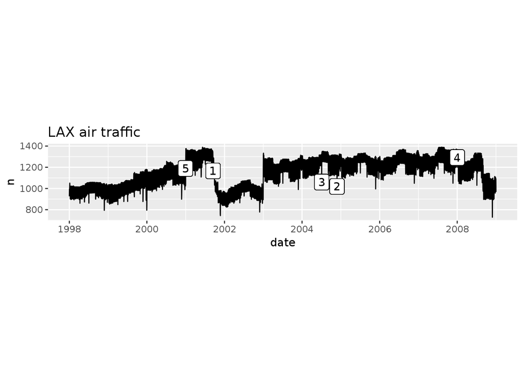

   ```r
   lax <- flights_tbl %>%
     filter(origin == "LAX" | dest == "LAX" &
            !is.na(year) & !is.na(month) & !is.na(dayofmonth)) %>%
     filter(year %in% c(1998:2008)) %>%
     select(origin, year, month, dayofmonth, dayofweek) %>%
     collect() %>%
     mutate(date = make_date(year, month, dayofmonth))
   # write_rds(lax, "q3lax.rds")
   # lax <- read_rds("q3lax.rds")

   ## generate plot ##
   q3_n <- lax %>%
     count(date)

   # get number of flights for labels
   lab1 <- q3_n %>%
     filter(date == ymd(20010915)) %>%
     select(n)
   lab2 <- q3_n %>%
     filter(date == ymd(20041125)) %>%
     select(n)
   lab3 <- q3_n %>%
     filter(date == ymd(20040704)) %>%
     select(n)
   lab4 <- q3_n %>%
     filter(date == ymd(20080101)) %>%
     select(n)
   lab5 <- q3_n %>%
     filter(date == ymd(20001229)) %>%
     select(n)

   q3a <- q3_n %>%
     ggplot(aes(x = date, y = n)) +
       geom_line() +
       coord_fixed() +
       ggtitle("LAX air traffic") +
       geom_label(aes(x = ymd(20010915), y = lab1, label = "1")) +
       geom_label(aes(x = ymd(20041125), y = lab2, label = "2")) +
       geom_label(aes(x = ymd(20040704), y = lab3, label = "3")) +
       geom_label(aes(x = ymd(20080101), y = lab4, label = "4")) +
       geom_label(aes(x = ymd(20001229), y = lab5, label = "5"))
   q3a
   ```

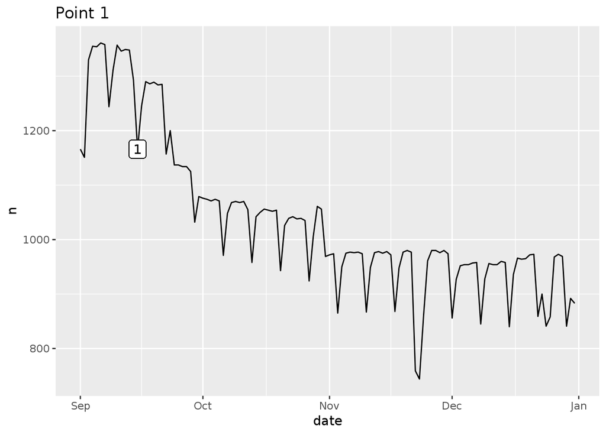

   ```r
   # ggsave("plot_q3a.png")

   # zoom in on each point
   q3_n %>%
     filter(date %in% c(ymd(20010901):ymd(20011231))) %>%
     ggplot(aes(x = date, y = n)) +
       geom_line() +
       geom_label(aes(x = ymd(20010915), y = lab1, label = "1")) +
       ggtitle("Point 1")
   ```

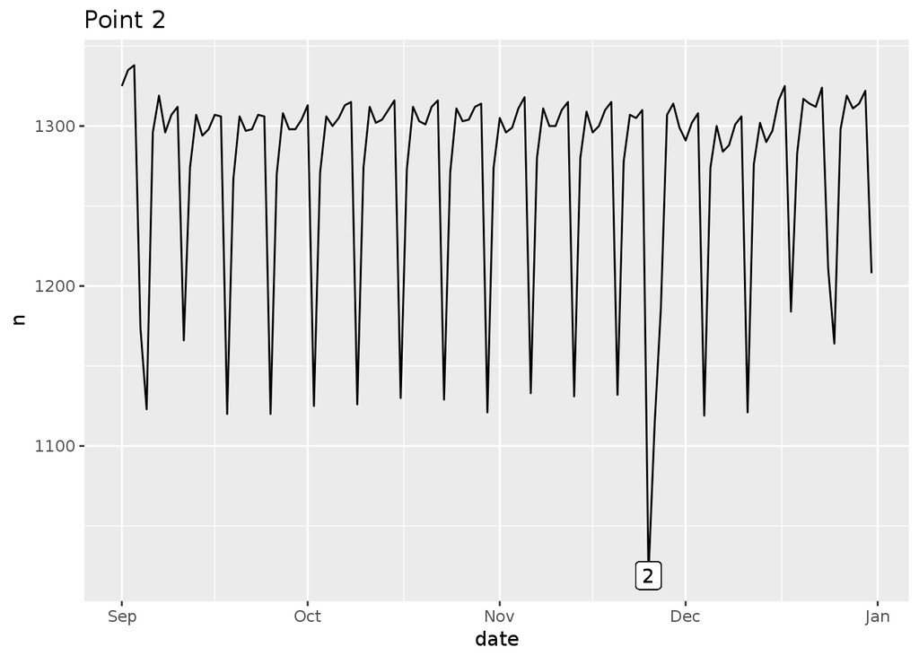

   ```r
   q3_n %>%
     filter(date %in% c(ymd(20040901):ymd(20041231))) %>%
     ggplot(aes(x = date, y = n)) +
       geom_line() +
       geom_label(aes(x = ymd(20041125), y = lab2, label = "2")) +
       ggtitle("Point 2")
   ```

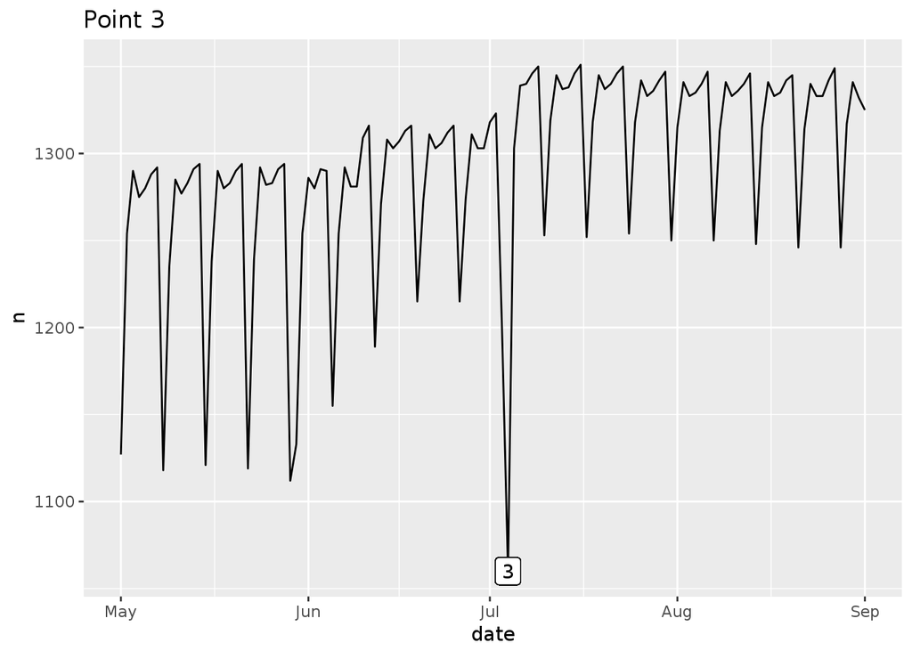

   ```r
   q3_n %>%
     filter(date %in% c(ymd(20040501):ymd(20040901))) %>%
     ggplot(aes(x = date, y = n)) +
       geom_line() +
       geom_label(aes(x = ymd(20040704), y = lab3, label = "3")) +
       ggtitle("Point 3")
   ```

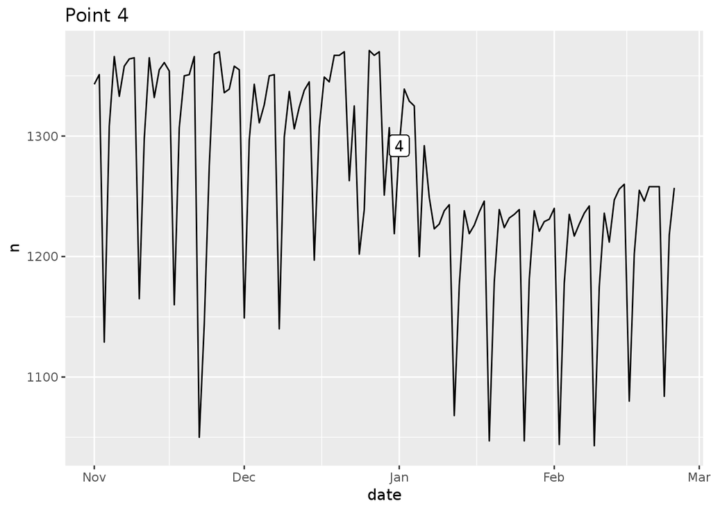

   ```r
   q3_n %>%
     filter(date %in% c(ymd(20071101):ymd(20080225))) %>%
     ggplot(aes(x = date, y = n)) +
       geom_line() +
       geom_label(aes(x = ymd(20080101), y = lab4, label = "4")) +
       ggtitle("Point 4")
   ```

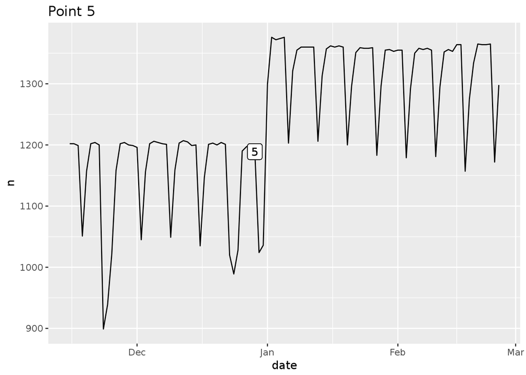

   ```r
   q3_n %>%
     filter(date %in% c(ymd(20001115):ymd(20010225))) %>%
     ggplot(aes(x = date, y = n)) +
       geom_line() +
       geom_label(aes(x = ymd(20001229), y = lab5, label = "5")) +
       ggtitle("Point 5")
   ```

   (b). Visualize and explain seasonal effects.  
   *I examined the seasonal pattern in air traffic through LAX for the years 2004 through 2007. It appears that summer consistently has the highest number of flights, and winter has the lowest number of flights. Because students are on summer break, families often travel more in the summer, which explains why the highest number of flights occurs in the summer. One possible reason for the lowest number of flights in winter is weather conditions, making travel less popular.*

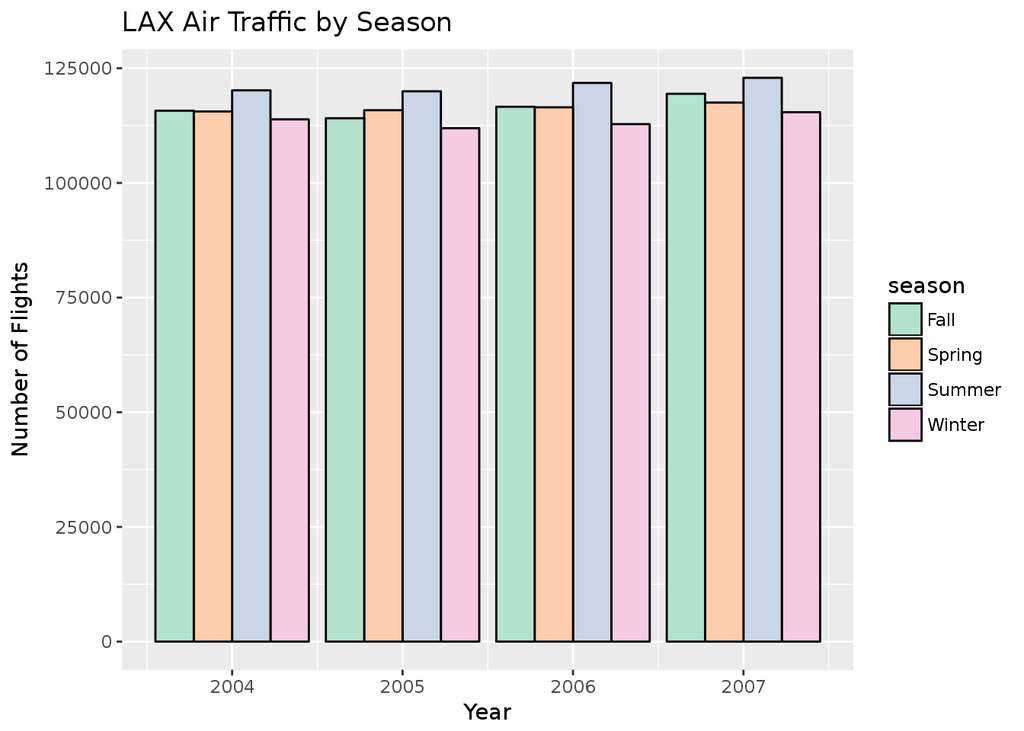

   ```r
   season <- lax %>%
     filter(year %in% c(2004:2007)) %>%
     mutate(season = if_else(month %in% c(12, 1, 2), "Winter",
                     if_else(month %in% c(3:5), "Spring",
                     if_else(month %in% c(6:8), "Summer",
                     if_else(month %in% c(9:11), "Fall", NA_character_))))) %>%
     count(year, season)

   q3b <- season %>%
     ggplot() +
       geom_col(aes(x = year, y = n, fill = season), position = "dodge",
                colour = "Black") +
       labs(x = "Year", y = "Number of Flights",
            title = "LAX Air Traffic by Season") +
       scale_fill_brewer(palette = "Pastel2")
   q3b
   ```

   ```r
   # ggsave("plot_q3b.png")
   ```

   (c). Visualize and explain weekly effects.  
   *I examined the weekly pattern in air traffic through LAX by counting the cumulative number of flights for each weekday from 1998 to 2008. The least amount of people fly on Saturday, and the highest amount of people fly on Friday or Monday. This makes sense, because people usually fly before/after the weekend so that they can enjoy their weekend where they want.*

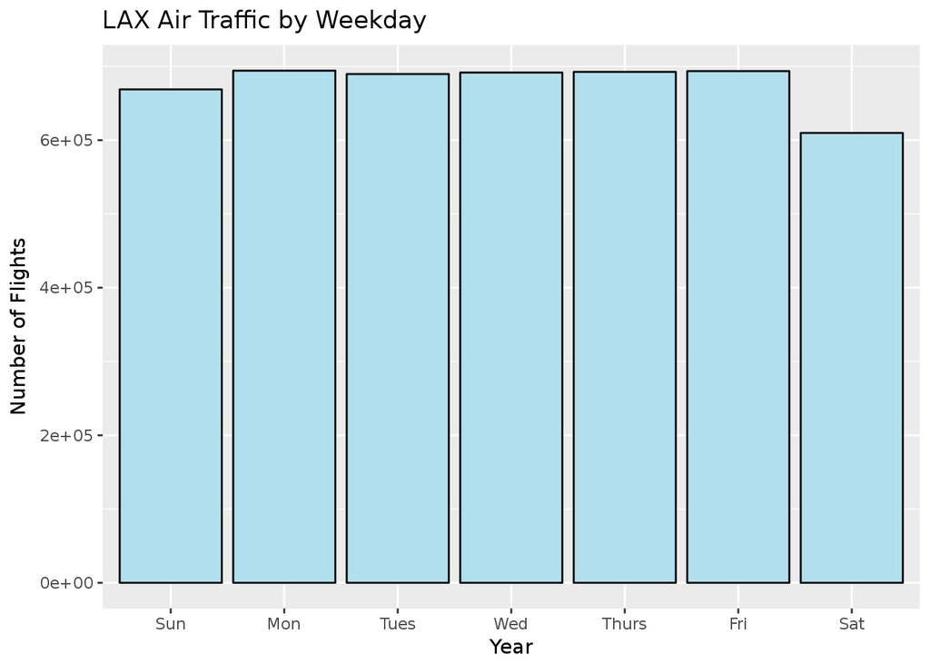

   ```r
   week <- lax %>%
     count(dayofweek) %>%
     mutate(Weekday = replace(dayofweek, c(1, 2, 3, 4, 5, 6, 7),
                              c("Mon", "Tues", "Wed", "Thurs", "Fri",
                                "Sat", "Sun")))

   arranged <- c("Sun", "Mon", "Tues", "Wed", "Thurs", "Fri", "Sat")
   q3c <- week %>%
     ggplot() +
       geom_col(aes(x = factor(Weekday, levels = arranged), y = n),
                fill = "lightblue2", color = "black") +
       labs(x = "Year", y = "Number of Flights",
            title = "LAX Air Traffic by Weekday")
   q3c
   ```

   ```r
   # ggsave("plot_q3c.png")
   ```

   (d). Map top 10 destinations from LAX. Size of dots should reflect the number of flights from LAX to that destination.  
   *I mapped the top 10 destinations from LAX. The most popular destination is SFO, with a cumulative total of 336,938 flights. A majority of the destinations cumulate on the West Coast (California, Arizona, Washington.*

[figure not shown]

   ```r
   lax_topdest <- flights_tbl %>%
     filter(origin == "LAX") %>%
     select(year, origin, dest) %>%
     count(dest) %>%
     arrange(desc(n)) %>%
     collect() %>%
     head(10)

   top_dest <- lax_topdest$dest
   airports_q3 <- airports_tbl %>%
     select(faa, lat, lon, name) %>%
     filter(faa %in% top_dest) %>%
     collect()
   q3d <- left_join(lax_topdest, airports_q3, by = c("dest" = "faa")) %>%
     rename(`Total Flights` = n)
   # write_rds(q3d, "q3d.rds")

   # convert lat and lon to numeric
   q3d$lat <- as.numeric(q3d$lat)
   q3d$lon <- as.numeric(q3d$lon)

   ## generate map ##
   lax_topdest_plot <- ggmap(map) +
     geom_point(aes(x = lon, y = lat, size = `Total Flights`),
                data = q3d, alpha = .75) +
     labs(x = "Longitude", y = "Latitude",
          title = "Top 10 Destinations from LAX") +
     geom_label_repel(data = q3d, label = q3d$dest, size = 2)
   lax_topdest_plot
   ```

   ```r
   # ggsave("plot_q3d.png")
   ```

4. Build a predictive model for the arrival delay (`arrdelay`) of flights flying from LAX. Use the same filtering criteria as in the [lecture notes](http://hua-zhou.github.io/teaching/biostatm280-2018winter/slides/12-sparklyr/sparklyr-flights.html) to construct training and validation sets. You are allowed to use a maximum of 5 predictors. The prediction performance of your model on the validation data set will be an important factor for grading this question.  
   *I filtered the records to flights flying from LAX and from the years 2003 to 2007. I partitioned the data into training and validation sets. I chose distance, departure delay, day of week, and actual elapsed time as my four predictors for arrival delay. I fitted a linear regression model from the training data and obtained a root MSE of 7.77.*

   ```r
   # filter records
   model_data <- flights_tbl %>%
     filter(origin == "LAX") %>%
     filter(!is.na(arrdelay) & !is.na(depdelay) & !is.na(distance)) %>%
     filter(depdelay > 15 & depdelay < 240) %>%
     filter(arrdelay > -60 & arrdelay < 360) %>%
     filter(year >= 2003 & year <= 2007) %>%
     mutate(weekday = as.character(dayofweek)) %>%
     select(year, month, weekday, arrdelay, depdelay, distance,
            actualelapsedtime)

   # summarize data by day of week
   model_data %>%
     group_by(weekday) %>%
     summarize(arrdelay = mean(arrdelay), distance = mean(distance),
               depdelay = mean(depdelay),
               actualelapsedtime = mean(actualelapsedtime)) %>%
     select(weekday, arrdelay, distance, depdelay, actualelapsedtime) %>%
     arrange(arrdelay)
   ```

   ```
   ## # Source:     lazy query [?? x 5]
   ## # Database:   spark_connection
   ## # Ordered by: arrdelay
   ##   weekday arrdelay distance depdelay actualelapsedtime
   ##   <chr>      <dbl>    <dbl>    <dbl>             <dbl>
   ## 1 6           42.6    1039.     46.6              152.
   ## 2 2           44.1    1042.     46.8              153.
   ## 3 3           44.4    1056.     46.6              155.
   ## 4 7           45.2     974.     47.4              145.
   ## 5 4           45.3    1020.     47.2              151.
   ## 6 1           45.5    1030.     47.5              152.
   ## 7 5           45.8     937.     47.7              141.
   ```

   ```r
   # Partition the data into training and validation sets
   model_partition <- model_data %>%
     sdf_partition(train = 0.8, valid = 0.2, seed = 5555)

   # Fit a linear model
   system.time(
     ml1 <- model_partition$train %>%
       ml_linear_regression(arrdelay ~ distance + depdelay + weekday +
                            actualelapsedtime)
   )
   ```

   ```
   ##    user  system elapsed
   ##   0.244   0.008 600.355
   ```

   ```r
   summary(ml1)
   ```

   ```
   ## Call: ml_linear_regression.tbl_spark(., arrdelay ~ distance + depdelay + weekday + actualelapsedtime)
   ##
   ## Deviance Residuals (approximate):
   ##      Min       1Q   Median       3Q      Max
   ## -58.1714  -4.1918   0.3951   4.1969 126.1553
   ##
   ## Coefficients:
   ##       (Intercept)          distance          depdelay         weekday_5
   ##      -25.26381831       -0.07696056        0.99432333        0.55540818
   ##         weekday_7         weekday_4         weekday_1         weekday_3
   ##        0.40796378        0.52462851        0.16959695        0.17431638
   ##         weekday_6 actualelapsedtime
   ##       -1.00427185        0.67508493
   ##
   ## R-Squared: 0.961
   ## Root Mean Squared Error: 7.771
   ```

   **Assess Model Performance**  
   *I compared the model performance using the validation data. I compared the training data and validation data by decile. From the bar chart, we can see that the predicted average arrival delay matched well with the validation data set.*

   ```r
   # Calculate average gains by predicted decile
   system.time(
     model_deciles <- lapply(model_partition, function(x) {
       sdf_predict(ml1, x) %>%
         mutate(decile = ntile(desc(prediction), 10)) %>%
         group_by(decile) %>%
         summarise(arrdelay = mean(arrdelay)) %>%
         select(decile, arrdelay) %>%
         collect()
     })
   )
   ```

   ```
   ##    user  system elapsed
   ##   0.188   0.004 219.997
   ```

   ```r
   # Create a summary dataset for plotting
   deciles <- rbind(
     data.frame(data = 'train', model_deciles$train),
     data.frame(data = 'valid', model_deciles$valid),
     make.row.names = FALSE
   )
   deciles
   ```

   ```
   ##     data decile   arrdelay
   ## 1  train      1 136.668662
   ## 2  train      2  79.308011
   ## 3  train      3  57.542818
   ## 4  train      4  44.665516
   ## 5  train      5  35.685927
   ## 6  train      6  29.199969
   ## 7  train      7  23.826964
   ## 8  train      8  19.367048
   ## 9  train      9  14.777991
   ## 10 train     10   7.361139
   ## 11 valid      1 136.360790
   ## 12 valid      2  79.219453
   ## 13 valid      3  57.965653
   ## 14 valid      4  44.917021
   ## 15 valid      5  35.672545
   ## 16 valid      6  28.837033
   ## 17 valid      7  23.649742
   ## 18 valid      8  19.100943
   ## 19 valid      9  14.970508
   ## 20 valid     10   7.732746
   ```

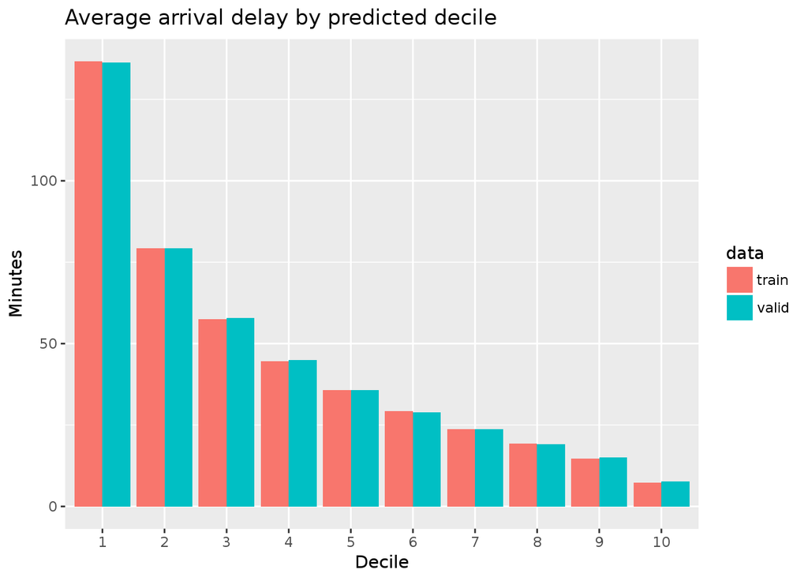

   ```r
   # Plot average gains by predicted decile
   deciles %>%
     ggplot(aes(factor(decile), arrdelay, fill = data)) +
       geom_bar(stat = 'identity', position = 'dodge') +
       labs(title = 'Average arrival delay by predicted decile',
            x = 'Decile', y = 'Minutes')
   ```

   ```r
   #ggsave("deciles.png")
   ```

   **Visualize Predictions**  
   *I compared predicted arrival delays to actual arrival delays from a test data set of 2008 data. I obtained a root MSE of 8.15 (as compared to the root MSE of 7.77 from the training set). The root MSE of the test set is similar to the training set, indicating that the model is good at predicting arrival delays.*

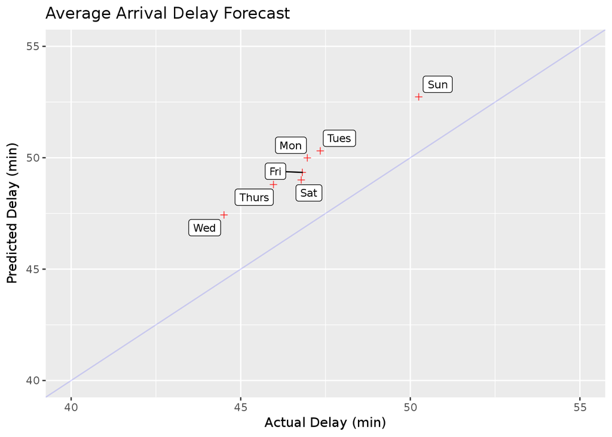

   ```r
   # Select data from an out of time sample
   data_2008 <- flights_tbl %>%
     filter(origin == "LAX") %>%
     filter(!is.na(arrdelay) & !is.na(depdelay) & !is.na(distance)) %>%
     filter(depdelay > 15 & depdelay < 240) %>%
     filter(arrdelay > -60 & arrdelay < 360) %>%
     filter(year == 2008) %>%
     mutate(weekday = as.character(dayofweek)) %>%
     select(year, weekday, arrdelay, depdelay, distance, actualelapsedtime)

   # get sum of squares
   test_model <- sdf_predict(data_2008, ml1) %>%
     mutate(SS = (prediction - arrdelay) ^ 2) %>%
     collect
   # write_rds(test_model, "test_model.rds")

   # calculate root MSE
   n <- test_model %>%
     summarise(n = n())
   root_mse <- sqrt(sum(test_model$SS) / n)

   # summarise data by weekday
   summary_data <- test_model %>%
     group_by(weekday) %>%
     summarise(arrdelay = mean(arrdelay), prediction = mean(prediction),
               freq = n()) %>%
     mutate(Weekday = replace(weekday, c(1, 2, 3, 4, 5, 6, 7),
                              c("Mon", "Tues", "Wed", "Thurs", "Fri",
                                "Sat", "Sun")))

   ggplot(summary_data, aes(arrdelay, prediction)) +
     geom_point(alpha = 0.75, color = 'red', shape = 3) +
     geom_abline(intercept = 0, slope = 1, alpha = 0.15, color = 'blue') +
     labs(title = 'Average Arrival Delay Forecast',
          x = 'Actual Delay (min)', y = 'Predicted Delay (min)') +
     geom_label_repel(data = summary_data, label = summary_data$Weekday,
                      size = 3) +
     xlim(40, 55) +
     ylim(40, 55)
   ```

5. Visualize and explain any other information you want to explore.  
   *I mapped the top 10 routes that had flights to SJC (San Jose International Airport) because that is my hometown, and I was interested in visualizing where the majority of people are visiting San Jose from. The results show that most flights are incoming from LAX and SAN (San Diego). This is consistent with my experience, as I often flew from SAN to SJC when I did my undergraduate education at UCSD, and now I fly from LAX to SJC.*

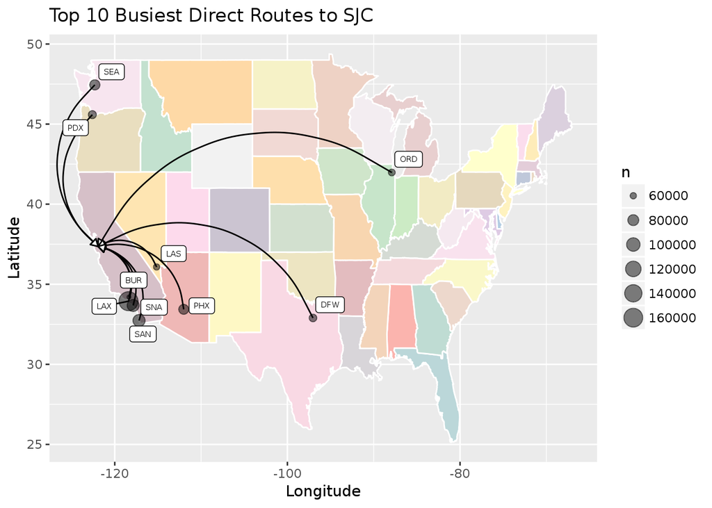

   ```r
   sjc_top <- flights_tbl %>%
     filter(dest == "SJC") %>%
     select(year, origin, dest) %>%
     count(origin) %>%
     arrange(desc(n)) %>%
     collect() %>%
     head(10)

   to_sjc <- sjc_top$origin
   airports_q5 <- airports_tbl %>%
     select(faa, lat, lon, name) %>%
     filter(faa %in% to_sjc) %>%
     collect()
   q5 <- left_join(sjc_top, airports_q5, by = c("origin" = "faa"))

   # convert lat and lon to numeric
   q5$lat <- as.numeric(q5$lat)
   q5$lon <- as.numeric(q5$lon)

   # write_rds(q5, "q5.rds")

   ## generate map ##
   state <- map_data("state")

   # customize region fill colors
   getPalette <- colorRampPalette(brewer.pal(9, "Pastel1"))

   sjc_plot <- ggplot(data = state) +
     geom_polygon(aes(x = long, y = lat, fill = region, group = group),
                  color = "white") +
                 coord_fixed(1.3) + guides(fill = FALSE) +
     geom_point(data = q5, aes(x = lon, y = lat, size = n), alpha = 0.5) +
     geom_curve(data = q5, aes(x = lon, y = lat,
                               xend = -121.9290, yend = 37.3626),
                arrow = arrow(length = unit(0.2, "cm"), type = "closed")) +
     geom_label_repel(aes(x = lon, y = lat), data = q5,
                      label = q5$origin, size = 2) +
     labs(x = "Longitude", y = "Latitude",
          title = "Top 10 Busiest Direct Routes to SJC") +
     scale_fill_manual(values = getPalette(49)) +
     coord_cartesian()
   sjc_plot
   ```

```r
spark_disconnect_all()
```

```
## [1] 1
```